# **Final Tutorial:**

**Killian Daly || Oliver Carleton**

# Webpage:

https://kdaly24.github.io/

# Goal

Every day, thousands of flights across America leave from busy airports containing hundreds of thousands of passengers. Every day, while most flights leave on time, many flights can be delayed due to a variety of factors, many of which are witheld from passengers. Our model seeks to answer a question any passenger has. Why is my flight delayed, and for how long will it be delayed?

Using linear regression, the goal to create a predictive model that uses historical flight data of the past five years (2019-2024) to estimate whether a flight will be delayed, and if so by how much. Based on the series of factors from our dataset, the model will output an estimated numerical minute value for the user. The model relies on features of historical data to make these predictions, such as airport location, departure time, and current weather data pulled from two separate airport datasets.

# Data Collection

Our datasets are pulled from a military America weather dataset, as well as a domestic airline dataset found on Kaggle. Links to our datasets are found below. For those interested in **further research** and testing, we can use any of the other datasets found at the other provided links to get insights as to other features, such as past specific plane ID (tracking number of past flights to determine if a plane may need spontaneous repair services which could cause delay).

CSV- flights_sample_3m.csv || /content/flights_sample_3m.csv.zip

API Dataset-

- Kaggle dataset (Airline Delays): Historical flight delay data, including flight times, causes of delays, and airports.
- RapidAPI for weather data: Retrieve weather conditions during flight departures for each airport.
- OpenSky Network API: Real-time and historical flight tracking data, which includes flight departures.

API links for Historical Flight and Weather Data-

https://rapidapi.com/collection/flight-data-apis

https://openskynetwork.github.io/opensky-api/rest.html

https://www.kaggle.com/datasets/sriharshaeedala/airline-delay

# Model

Our specific model utilized a handful of selected features for linear regression, but you can use any number of features and adjacent model types and achieve different results.

Some suggested models worth exploring for those looking to **further this tutorial and deepdive** would be a K-Nearest Neighbor Model.

Find more information here: https://www.geeksforgeeks.org/k-nearest-neighbours/

# Collaboration Plan

To ensure we stay on track with the project roadmap and meet all assignment requirements, we will hold weekly progress meetings. These meetings will serve to review our milestones, address any roadblocks, and adjust our timeline if necessary.

Work will be evenly distributed, with both parties contributing equally to the project in terms of coding and writing. Each team member will take responsibility for completing their assigned tasks within the agreed-upon deadlines, ensuring a balance of effort in all aspects of the project.

The first few lines of our code import a series of libraries that we will need for this project, including seaborn and pandas.

Additionally, we have mounted our google drive folder to utilize the downloaded kaggle airport flight delay dataset as a dataframe in python.

```python
%%shell
jupyter nbconvert --to html /content/drive/MyDrive/Daly-Carleton-Tutorial.ipynb
```

```python
from google.colab import drive
drive.mount('/content/drive')
```

```python
import pandas as pd #Importing all necessary libraries
import numpy as np
import matplotlib.pyplot as plt
import seaborn as sns
from sklearn.preprocessing import OrdinalEncoder
from sklearn.model_selection import train_test_split
from sklearn.linear_model import LinearRegression
from sklearn.metrics import mean_squared_error, r2_score

df = pd.read_csv('/content/drive/MyDrive/flights_sample_3m.csv') #Reading to a dataframe

df.head()
```

|  | FL_DATE | AIRLINE | AIRLINE_DOT | AIRLINE_CODE | DOT_CODE | FL_NUMBER | ORIGIN | ORIGIN_CITY | DEST | DEST_CITY | ... | DIVERTED | CRS_ELAPSED_TIME | ELAPSED_TIME | AIR_TIME | DISTANCE | DELAY_DUE_CARRIER | DELAY_DUE_WEATHER | DELAY_DUE_NAS | DELAY_DUE_SECURITY | DELAY_DUE_LATE_AIRCRAFT |
| --- | --- | --- | --- | --- | --- | --- | --- | --- | --- | --- | --- | --- | --- | --- | --- | --- | --- | --- | --- | --- | --- |
| 0 | 2019-01-09 | United Air Lines Inc. | United Air Lines Inc.: UA | UA | 19977 | 1562 | FLL | Fort Lauderdale, FL | EWR | Newark, NJ | ... | 0.0 | 186.0 | 176.0 | 153.0 | 1065.0 | NaN | NaN | NaN | NaN | NaN |
| 1 | 2022-11-19 | Delta Air Lines Inc. | Delta Air Lines Inc.: DL | DL | 19790 | 1149 | MSP | Minneapolis, MN | SEA | Seattle, WA | ... | 0.0 | 235.0 | 236.0 | 189.0 | 1399.0 | NaN | NaN | NaN | NaN | NaN |
| 2 | 2022-07-22 | United Air Lines Inc. | United Air Lines Inc.: UA | UA | 19977 | 459 | DEN | Denver, CO | MSP | Minneapolis, MN | ... | 0.0 | 118.0 | 112.0 | 87.0 | 680.0 | NaN | NaN | NaN | NaN | NaN |
| 3 | 2023-03-06 | Delta Air Lines Inc. | Delta Air Lines Inc.: DL | DL | 19790 | 2295 | MSP | Minneapolis, MN | SFO | San Francisco, CA | ... | 0.0 | 260.0 | 285.0 | 249.0 | 1589.0 | 0.0 | 0.0 | 24.0 | 0.0 | 0.0 |
| 4 | 2020-02-23 | Spirit Air Lines | Spirit Air Lines: NK | NK | 20416 | 407 | MCO | Orlando, FL | DFW | Dallas/Fort Worth, TX | ... | 0.0 | 181.0 | 182.0 | 153.0 | 985.0 | NaN | NaN | NaN | NaN | NaN |

5 rows × 32 columns

```python
from sklearn.model_selection import train_test_split
from sklearn.linear_model import LinearRegression
from sklearn.metrics import mean_squared_error, r2_score
from sklearn.preprocessing import OneHotEncoder
```

```python
df.rename(columns={
    'FL_DATE': 'Flight Date',
    'AIRLINE': 'Airline Name',
    'AIRLINE_DOT': 'Airline Dot Code',
    'AIRLINE_CODE': 'Airline Code',
    'DOT_CODE': 'Dot Code',
    'FL_NUMBER': 'Flight Number',
    'ORIGIN': 'Origin Airport',
    'ORIGIN_CITY': 'Origin City',
    'DEST': 'Destination Airport',
    'DEST_CITY': 'Destination City',
    'CRS_ELAPSED_TIME': 'CRS Elapsed Time',
    'ELAPSED_TIME': 'Elapsed Time',
    'AIR_TIME': 'Air Time',
    'DISTANCE': 'Distance',
    'DELAY_DUE_CARRIER': 'Delay Due To Carrier',
    'DELAY_DUE_WEATHER': 'Delay Due To Weather',
    'DELAY_DUE_NAS': 'Delay Due To Nas',
    'DELAY_DUE_SECURITY': 'Delay Due To Security',
    'DELAY_DUE_LATE_AIRCRAFT': 'Delay Due To Late Aircraft'
}, inplace=True)
# Running these lines to rename our columns to proper terms for our use. Since our data is obtained from a government database, much of the tidy data principles are followed already.
df.head()
```

|  | Flight Date | Airline Name | Airline Dot Code | Airline Code | Dot Code | Flight Number | Origin Airport | Origin City | Destination Airport | Destination City | ... | DIVERTED | CRS Elapsed Time | Elapsed Time | Air Time | Distance | Delay Due To Carrier | Delay Due To Weather | Delay Due To Nas | Delay Due To Security | Delay Due To Late Aircraft |
| --- | --- | --- | --- | --- | --- | --- | --- | --- | --- | --- | --- | --- | --- | --- | --- | --- | --- | --- | --- | --- | --- |
| 0 | 2019-01-09 | United Air Lines Inc. | United Air Lines Inc.: UA | UA | 19977 | 1562 | FLL | Fort Lauderdale, FL | EWR | Newark, NJ | ... | 0.0 | 186.0 | 176.0 | 153.0 | 1065.0 | NaN | NaN | NaN | NaN | NaN |
| 1 | 2022-11-19 | Delta Air Lines Inc. | Delta Air Lines Inc.: DL | DL | 19790 | 1149 | MSP | Minneapolis, MN | SEA | Seattle, WA | ... | 0.0 | 235.0 | 236.0 | 189.0 | 1399.0 | NaN | NaN | NaN | NaN | NaN |
| 2 | 2022-07-22 | United Air Lines Inc. | United Air Lines Inc.: UA | UA | 19977 | 459 | DEN | Denver, CO | MSP | Minneapolis, MN | ... | 0.0 | 118.0 | 112.0 | 87.0 | 680.0 | NaN | NaN | NaN | NaN | NaN |
| 3 | 2023-03-06 | Delta Air Lines Inc. | Delta Air Lines Inc.: DL | DL | 19790 | 2295 | MSP | Minneapolis, MN | SFO | San Francisco, CA | ... | 0.0 | 260.0 | 285.0 | 249.0 | 1589.0 | 0.0 | 0.0 | 24.0 | 0.0 | 0.0 |
| 4 | 2020-02-23 | Spirit Air Lines | Spirit Air Lines: NK | NK | 20416 | 407 | MCO | Orlando, FL | DFW | Dallas/Fort Worth, TX | ... | 0.0 | 181.0 | 182.0 | 153.0 | 985.0 | NaN | NaN | NaN | NaN | NaN |

5 rows × 32 columns

# **Data Principle Applications**

The dataset shown in the image follows tidy data principles because each column contains a single variable ("Flight Date," "Airline Name," "Origin City"), each row represents an observation (a single flight), and there is a uniform structure for missing data (with `NaN` indicating missing values). The column names are descriptive and meaningful, and the data is organized such that each variable forms a column and each type of observation forms a row.

# Extraction, Transformation, Loading (ETL) - Load and Tidy Data

- Datset contains flight related data including flight dates, airline names, orgin and destination airports and various delay causes such as carrier weather and air traffic control issues.
- Dataset used to answer questions related to flight puntuality. Identifying patterns that lead to delyas and analyzing performace difference across airlines, assecin impact of weahter on flight schedules.
- The dataset is open-access from Kaggle collected using airlines, airpiort, Department of Transportation DOT, and Bureau of Transportation Statistics BTS.

Tidy Data Principles

- Each Variable forms a column
- Each Obervation forms a row
- Each Obervational unit forms a table

```python
df.info() # As we can see here, all of our categorical variables are "objects" whilst our critical numerical observations are represented in ints or floats. This is a big first step of our tidy data principles already accomplished!
```

```
<class 'pandas.core.frame.DataFrame'>
RangeIndex: 3000000 entries, 0 to 2999999
Data columns (total 32 columns):
 #   Column                      Dtype
---  ------                      -----
 0   Flight Date                 object
 1   Airline Name                object
 2   Airline Dot Code            object
 3   Airline Code                object
 4   Dot Code                    int64
 5   Flight Number               int64
 6   Origin Airport              object
 7   Origin City                 object
 8   Destination Airport         object
 9   Destination City            object
```

[output cut: 24 more lines]

```python
df['Airline Name'].unique() # Here we can see all the major airlines we will be using from this dataset. It includes common household brands like United and Delta, as well as lesser known ones.
```

```
array(['United Air Lines Inc.', 'Delta Air Lines Inc.',
       'Spirit Air Lines', 'Southwest Airlines Co.',
       'American Airlines Inc.', 'Republic Airline',
       'Alaska Airlines Inc.', 'JetBlue Airways', 'PSA Airlines Inc.',
       'Allegiant Air', 'ExpressJet Airlines LLC d/b/a aha!',
       'SkyWest Airlines Inc.', 'Endeavor Air Inc.', 'Envoy Air',
       'Frontier Airlines Inc.', 'Mesa Airlines Inc.', 'Horizon Air',
       'Hawaiian Airlines Inc.'], dtype=object)
```

```python
sub_df = df[['Origin City','CRS_DEP_TIME','DEP_TIME','Flight Date',"DEP_DELAY",'CANCELLED','DIVERTED']] # We create a sub-dataframe of just key statistics for further analysis.
```

```python
top_3_cities = df['Origin City'].value_counts().nlargest(3).index.tolist()  # This contains just top three most used airports, which we can combine with the previous dataframe.
sub_df_top_3 = sub_df[sub_df['Origin City'].isin(top_3_cities)] #Thus creating a dataframe of only the top three cities and their most relevant statistics. This may be useful for further EDA.
```

```python
delay_frequency_by_airline = (df.groupby('Airline Name')['DEP_DELAY'].apply(lambda x: (x > 15).mean()) * 100).sort_values(ascending=False)
delay_frequency_by_airline #Using a groupby with a lambda function we can aggregate all rows where the flight was delayed by a relevant amount of time, i.e. more than 15 minutes.
#Then, we calculate the frequency of this relative to the airline.
```

| Airline Name | DEP_DELAY |
| --- | --- |
| JetBlue Airways | 25.661976 |
| Frontier Airlines Inc. | 25.158999 |
| Allegiant Air | 21.900717 |
| Southwest Airlines Co. | 21.084185 |
| Spirit Air Lines | 20.411447 |
| American Airlines Inc. | 18.239861 |
| United Air Lines Inc. | 17.591472 |
| ExpressJet Airlines LLC d/b/a aha! | 16.864060 |
| Mesa Airlines Inc. | 16.330831 |
| Alaska Airlines Inc. | 15.048722 |
| PSA Airlines Inc. | 14.844465 |
| Envoy Air | 13.941578 |
| SkyWest Airlines Inc. | 13.867579 |
| Delta Air Lines Inc. | 13.749655 |
| Hawaiian Airlines Inc. | 13.330635 |
| Republic Airline | 12.545159 |
| Horizon Air | 12.111079 |
| Endeavor Air Inc. | 11.441985 |

**dtype:** float64

```python
avg_delay_by_airline = df.groupby('Airline Name')['DEP_DELAY'].mean().sort_values(ascending=False) # Here we can use a groupby to gather all flights and sort by mean departure delays.
avg_delay_by_airline #Here we can see similarities between the delays.
```

| Airline Name | DEP_DELAY |
| --- | --- |
| JetBlue Airways | 18.322555 |
| Frontier Airlines Inc. | 16.033574 |
| Allegiant Air | 13.907797 |
| Spirit Air Lines | 12.981880 |
| ExpressJet Airlines LLC d/b/a aha! | 12.774462 |
| American Airlines Inc. | 12.609895 |
| Mesa Airlines Inc. | 12.277383 |
| United Air Lines Inc. | 11.217032 |
| Southwest Airlines Co. | 10.816957 |
| SkyWest Airlines Inc. | 9.458294 |
| Delta Air Lines Inc. | 8.106748 |
| PSA Airlines Inc. | 7.972124 |
| Envoy Air | 6.728256 |
| Endeavor Air Inc. | 5.951135 |
| Republic Airline | 5.804359 |
| Hawaiian Airlines Inc. | 5.089537 |
| Horizon Air | 4.832775 |
| Alaska Airlines Inc. | 4.640018 |

**dtype:** float64

```python
airline_performance = pd.DataFrame({ # Let's now take our statistics from above regarding delay and create a dataframe of just these points so we can easily use them for a graphic.
    'Delay Frequency (%)': delay_frequency_by_airline,
    'Average Delay Length (min)': avg_delay_by_airline
})
```

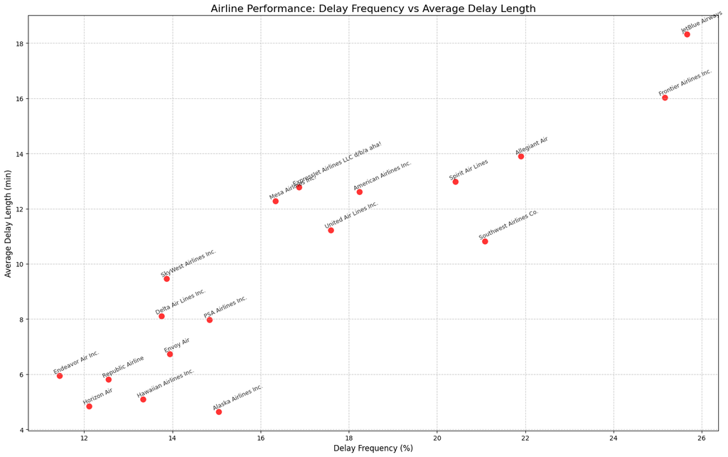

```python
plt.figure(figsize=(16, 10)) # Here we create a graphic to depict airline performance by comparing the average likelihood of a delay to the length of said delay.
sns.scatterplot(x='Delay Frequency (%)', y='Average Delay Length (min)', data=airline_performance, color = 'red', s=100, alpha = .8)
# Here we add labels for each point on the graph.
for id, row in airline_performance.iterrows():
    plt.annotate(id, (row['Delay Frequency (%)'], row['Average Delay Length (min)']), xytext=(-10,3), color = 'black', textcoords='offset points', fontsize=9, alpha=0.8, rotation = 25)
# Offset and rotation here is key to avoid overlapping text annotations.
plt.title('Airline Performance: Delay Frequency vs Average Delay Length', fontsize=16)
plt.xlabel('Delay Frequency (%)', fontsize=12)
plt.ylabel('Average Delay Length (min)', fontsize=12)
plt.grid(True, linestyle='--', alpha=0.7)
plt.tight_layout()
plt.show()
```